# Лабораторная работа №7

Операционные системы

Назармамадов У.ДЖ.

Российский университет дружбы народов, Москва, Россия

Объединённый институт ядерных исследований, Дубна, Россия

18 марта 2024

# Информация

## Докладчик

- Назармамадов Умед Джамшедович
- студент, 1 курс, группа НКАбд-04-23
- Российский университет дружбы народов
- [1032225205@rudn.ru]
- https://github.com/udnazarmamadov/

# Цель работы

Ознакомление с файловой системой Linux, её структурой, именами и содержанием каталогов. Приобретение практических навыков по применению команд для работы с файлами и каталогами, по управлению процессами (и работами), по проверке исполь- зования диска и обслуживанию файловой системы.

# Выполнение лабораторной работы

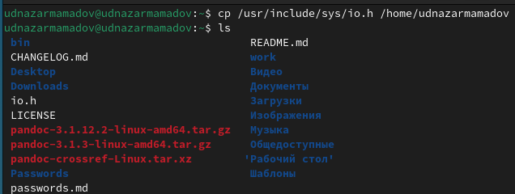

Копирование файла

# Выполнение лабораторной работы

В домашнем каталоге создаю директорию ~/ski.plases.

# Выполнение лабораторной работы

С помощью определенной команды перемещаю файл equipment в каталог ~/ski.plases.

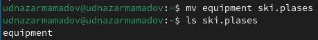

Перемещение файла

# Выполнение лабораторной работы

Перемещаю файл ~/ski.plases/equipment в ~/ski.plases/equiplist.

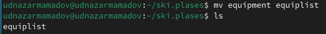

Перемещение файла

# Выполнение лабораторной работы

Создаю в домашнем каталоге файл abc1 и копирую его в каталог ~/ski.plases, называю его equiplist2. Создаю каталог с именем equipment в каталоге ~/ski.plases.

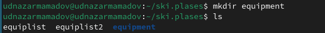

Создание

# Выполнение лабораторной работы

Перемещаю файлы ~/ski.plases/equiplist и equiplist2 в каталог ~/ski.plases/equipment.

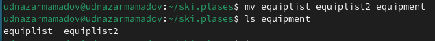

Перемещение файла

# Выполнение лабораторной работы

Создаю и перемещаю каталог ~/newdir в каталог ~/ski.plases и переименовываю его plans.

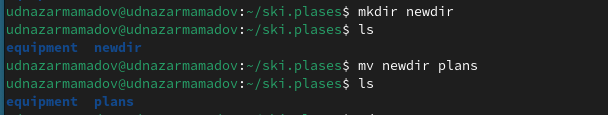

Перемещение файла

# Выполнение лабораторной работы

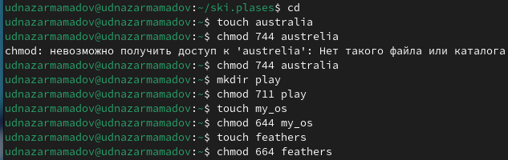

Команда chmod

# Выполнение лабораторной работы

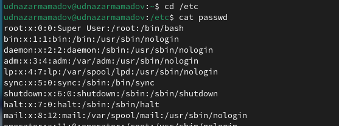

Содержимое файла

# Выполнение лабораторной работы

Копирую файл ~/feathers в файл ~/file.old.

# Выполнение лабораторной работы

Переместите файл ~/file.old в каталог ~/play.

# Выполнение лабораторной работы

Копирую каталог ~/play в каталог ~/fun.

# Выполнение лабораторной работы

Переместите каталог ~/fun в каталог ~/play и назовите его games.

# Выполнение лабораторной работы

Лишаю владельца файла ~/feathers права на чтение.

# Выполнение лабораторной работы

После лишение прав владельца просмотреть файл ~/feathers командой cat у меня не получается. Скопировать файл ~/feathers тоже.

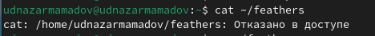

Просмотр файла

# Выполнение лабораторной работы

Даю обратно владельцу файла ~/feathers право на чтение.

# Выполнение лабораторной работы

Лишаю владельца каталога ~/play права на выполнение.

# Выполнение лабораторной работы

Перехожу в каталог ~/play. В результате ничего не получится, потому что мне отказано в доступе.

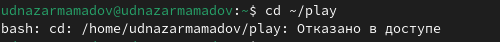

Каталог

# Выполнение лабораторной работы

Даю владельцу каталога ~/play право на выполнение.

# Вывод